# Functional Analysis and Business Logic of the Mobile Activity Tracking System

Guidelines for Operational Scenarios, User Interface Tabs, and Agricultural Labor Compliance Control

Author

Core Infrastructure & Simulation Framework Documentation

Published

June 11, 2026

## 1 Introduction and Purpose of the Document

This specification provides a comprehensive description of the business logic and operational scenarios for the mobile application developed using the **Flutter** framework. The document is tailored for business analysts, product managers (Product Owners), and operational controllers, ensuring a transparent understanding of how the system’s active screens are structured and the specific validation rules governing how employee activities are logged.

The mobile application operates as an **automated workstation for agricultural sector field workers** (inspectors, surveyors, manual laborers) who execute physical, technical tasks across scattered operational facilities (fields, plots).

### 1.1 Core Business Objective of the System

To provide instantaneous and verified tracking of actual physical fieldwork on the ground, backed by confirmation of the employee’s genuine location presence on-site. Based on the logs and timestamps captured by the application, the system automatically computes the **Labor Contribution Coefficient (LCC)** and handles payroll calculations.

## 2 Interface Architecture (Blueprint) and Application Workspaces

The primary operational workspace is separated into two navigation tabs (Tabs) to facilitate independent data transmission pipelines directed at distinct backend API endpoints.

##### Шаг 2: Старт активности

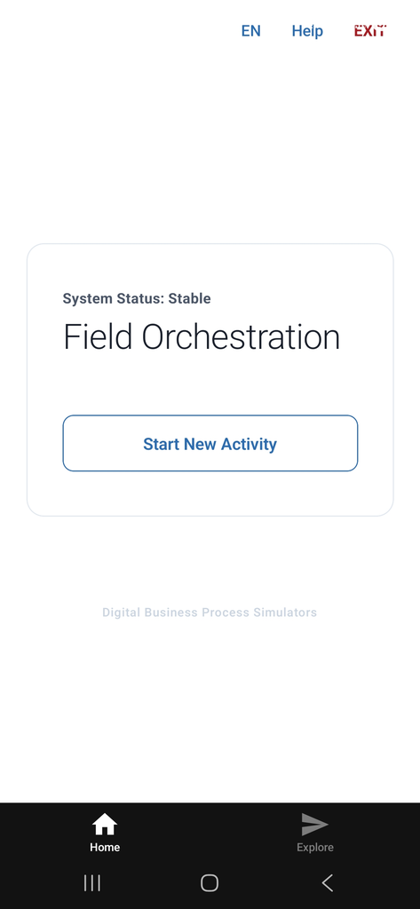

##### Шаг 3: Выбор компании

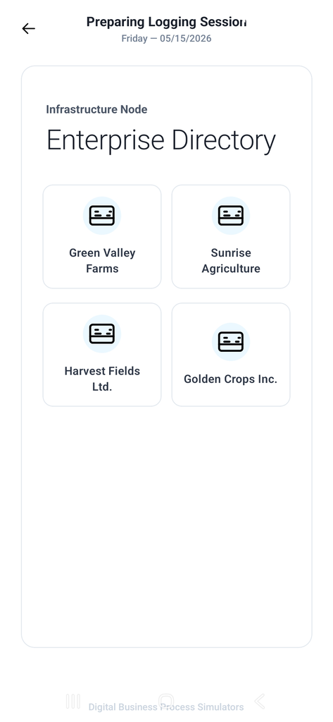

##### Шаг 4: Выбор поля

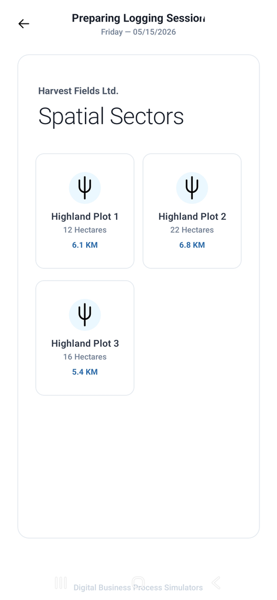

##### Шаг 5: Выбор активности

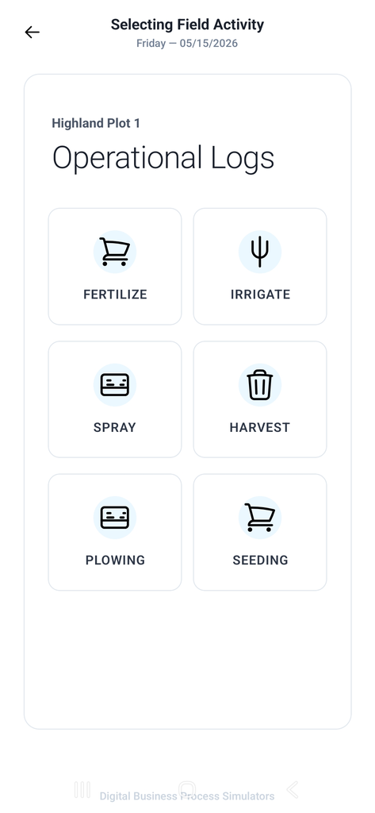

##### Шаг 6-7: Вкладка VOICE 1

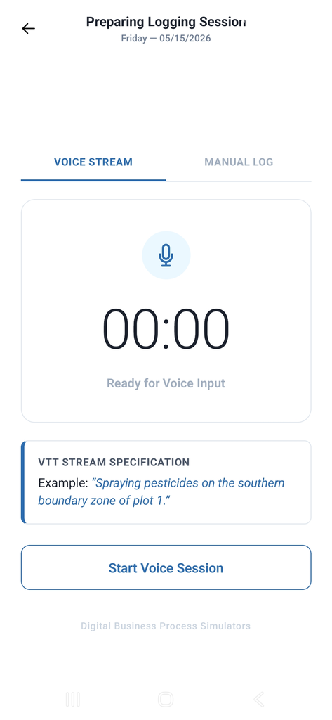

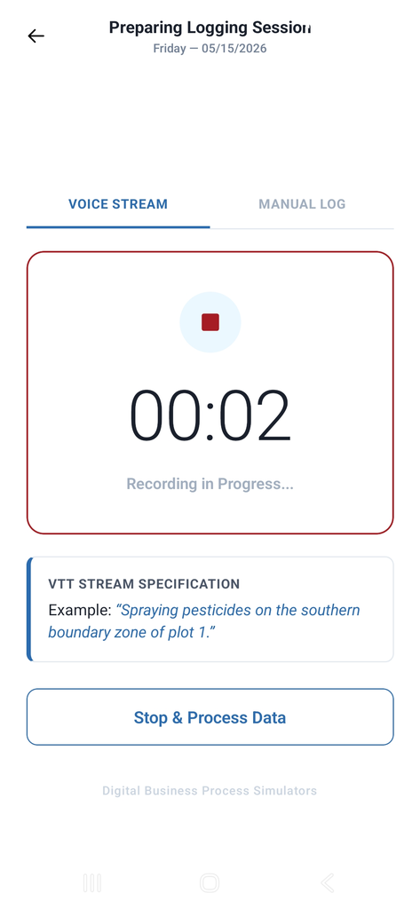

##### Шаг 8-9: Вкладка VOICE 2

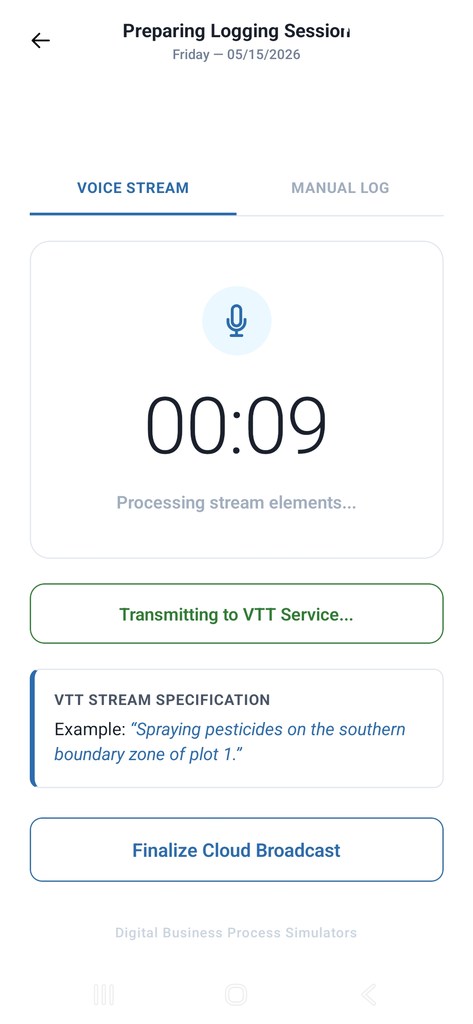

[figure not shown]

##### Шаг 10-12: Вкладка MANUAL

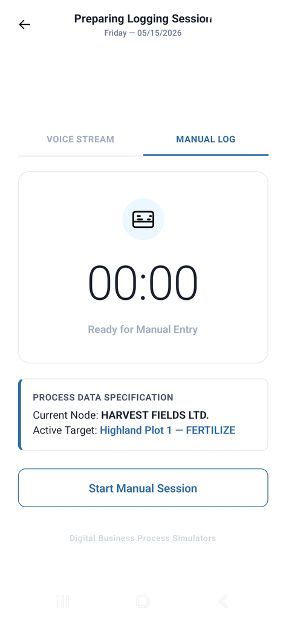

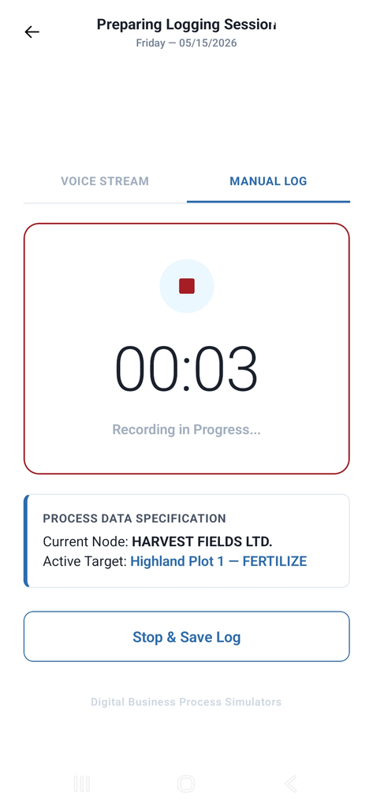

##### Шаг 13: Вкладка MANUAL

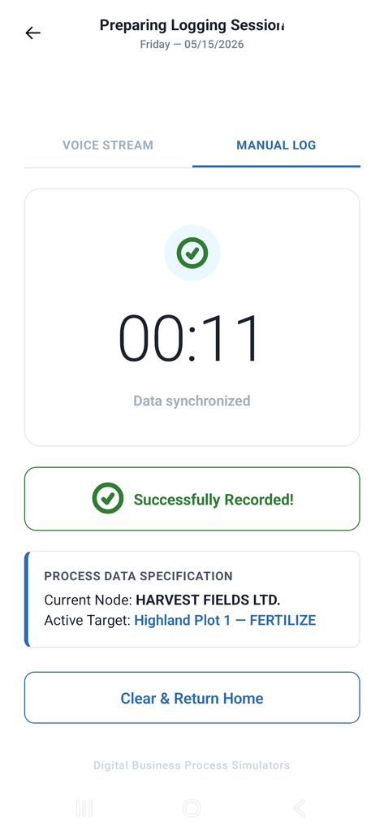

[figure not shown]

## 3 The Shared Edge Node Concept[^1] and Digital Agents

The system architecture is engineered on the principle of a **Shared Edge Node**. This implies that a unified Application Programming Interface (API) and its underlying logical boundary constraints serve two distinct types of entities simultaneously:

- **Human Operators:** Use the mobile application directly on their smartphones. The user interface is heavily optimized for hazardous, real-world field environments (e.g., dirty hands, screen glare, limited time constraints) and aggressively minimizes manual keyboard entry.
- **Digital Agents (Software Simulators):** Specialized bot-twins that programmatic replicate human actions. They dispatch identical data packets, generate identically structured media streams, and traverse the exact same backend validation pipelines. This allows the system to gather massive synthetic datasets for backend load testing and for training analytical models.

## 4 Three Fundamental Phases of Mobile Workstation Execution

The operational workflow of the mobile application is divided into three isolated functional phases, which sequentially transition the state of the active user session from initialization to final submission:

### 4.1 Phase 1: Authorization and Coordination (Permissions Matrix)

Upon logging into the app, the operator submits their credentials. The system interrogates the central registry and executes a comprehensive profile coordination sequence:

- It maps the active legal contracts to determine the user’s corporate affiliations (`worker_companies`).
- It constructs a strictly bounded list of physical fields and operational sectors assigned to that specific operator.
- It injects an individualized **permissions matrix** — a whitelist of permitted technical actions (e.g., “Irrigation Check” or “Visual Scouting” only), completely blocking unauthorized field activities.

### 4.2 Phase 2: Covert Background Geo-Tracking and Forensic Auditing

Following successful credential validation and session parameter configuration in Phase 1, the operator activates the assigned task and initiates fieldwork operations. At this precise point, one of the platform’s core compliance guardrails engages — **covert background location tracking**.

- **Zero Client-Side Interventions:** The mobile application UI is explicitly designed to **never interrupt worker operations** or flash warning alerts regarding spatial boundary infractions on screen. This intentional omission ensures that a non-compliant operator cannot deduce valid coordinate ranges via simple trial and error while sitting off-site or away from the designated operational zone (provided as an illustrative example).
- **Harvesting the Forensic Evidence Trail:** The application interface behaves completely normally on the surface, returning an `HTTP 202 Accepted` packet status to the user. Behind the scenes, however, the background geolocation module continuously samples and appends actual GPS telemetry tracks.
- **Impact of Geo-Fraud on Payroll and Contribution Indexes:** If the backend cross-references spatial telemetry and uncovers a violation (such as moving past the designated asset center beyond the predefined boundary clearance threshold of N meters), the entire transaction is tagged as compromised. This record is routed immediately to the Forensic Audit circuit for automated recalculation of the worker’s contribution index, nullifying the current shift’s work ticket and generating an accounting log to block labor payout distributions.

### 4.3 Phase 3: Two-Component Reporting (Input Ergonomics)

The primary operational workspace presents the operator with two alternate navigation tabs to submit the final task execution report, separating data pipelines into dedicated voice and manual interfaces.

#### 4.3.1 The VOICE Tab: Asynchronous Voice Reporting and Downstream Adjustments

Engineered for hands-free, rapid transactional updates under hazardous field conditions where typing text into a smartphone screen is impractical.

#### 4.3.2 The MANUAL Tab: Manual Time-Tracking[^2] and Automated Session Terminations

Utilized primarily in scenarios with high ambient noise interference (e.g., operation of heavy internal combustion engines, water pump stations) or in complete cellular network dead zones on-site.

- **START/STOP Trigger Logic:** The operator logs the exact initiation and completion steps of physical tasks by pressing dedicated on-screen navigation buttons. The system computes the net minutes of active time-tracking, caching the corresponding GPS coordinates at both the open and close points of the process.
- **Session Lifecycle Under App Backgrounding and Device Locking:** The mobile client supports **complete state persistence across focus loss events**. If the employee minimizes the application, locks the screen, stores the smartphone in a pocket, or answers an incoming voice call, the internal active session timer remains uncompromised. The tracking thread and background GPS telemetry collection continue to execute continuously in the background operating system environment.
- **Automated Session Interruption and Compliance Rejections:** If an operator forgets to tap the “STOP” button and leaves the facility (e.g., drives home), a protective system timeout rule engages. Upon exceeding the maximum regulatory threshold for a standard field operation (more than 8 continuous hours on a single work ticket), the backend executes an **automated forced session termination**.
  - *Work Ticket Voiding and Contribution Metric Zeroing:* Such deviancies are automatically flagged as invalid by the processing algorithm. The logged labor duration for the ticket is reset to zero, no contribution index metrics are awarded for the shift, and a high-priority system incident is pushed to the administrator grid to initiate a formal timesheet inflation audit.

## 5 Future Platform Evolution: Operational Group Expansion

The established shared-edge architectural model[^3] and its accompanying data pathways were fundamentally engineered with horizontal scalability in mind. The long-term product roadmap plans a sequential transition from tracking purely manual human labor to coordinating mixed enterprise operational fleets.

The Apache Kafka message broker schemas and underlying persistent database storage tables already contain extension fields to natively support two new functional groups:

1. **Automated and Piloted Machinery Fleet:** Integration of onboard vehicle computer telemetry, ignition tracking modules, and fuel flow sensors to capture and evaluate mechanized operational tasks.
2. **Autonomous Robotic Hardware:** Connectivity vectors for autonomous wheeled ground platforms, automated drip-irrigation networks, and unmanned aerial vehicle (UAV) scout drones. These robotic nodes will stream their operational coordinate meshes and mission completion logs into the exact same unified session history tables (`process_chronology`), enabling seamless cross-verification and generating cohesive Process Mining maps across the entire industrial enterprise.

## 6 Conclusion

The functional analysis and business logic design of the client-side perimeter for the mobile application, built on the **Flutter** framework, have successfully delivered an effective automated workstation for field operators. This client is fully integrated into the platform’s unified event-driven infrastructure.

1. **Ergonomics and Non-Blocking Interface:** Separating operational workflows into asynchronous voice inputs (VOICE tab) and manual chronometry (MANUAL tab) completely isolates the application UI from heavy server-side processing. The user receives instantaneous system responsiveness, while all AI transcription and parsing occur asynchronously in the background, eliminating any operational workflow interruptions.
2. **Fraud Prevention and Verification of Contribution Metrics:** Implementing covert background location tracking (geofencing) paired with automated forced session terminations upon exceeding time boundaries successfully hardens the system against timesheet manipulation and hours inflation. Incorporating intermediary text-based “Draft” report screens ensures overall data consistency even when encountering AI translation or transcription ambiguities.

The engineered layout architecture, transition scenarios, and background processes serve as a unified Shared-Edge standard. This design guarantees absolute identity between the operational traces generated by live field employees and those generated by the autonomous simulation agents, establishing a dependable foundation for automated payroll accounting and comprehensive, end-to-end business intelligence analytics.